# P4 - Análise Exploratória de Dados

### Bancos

Índices

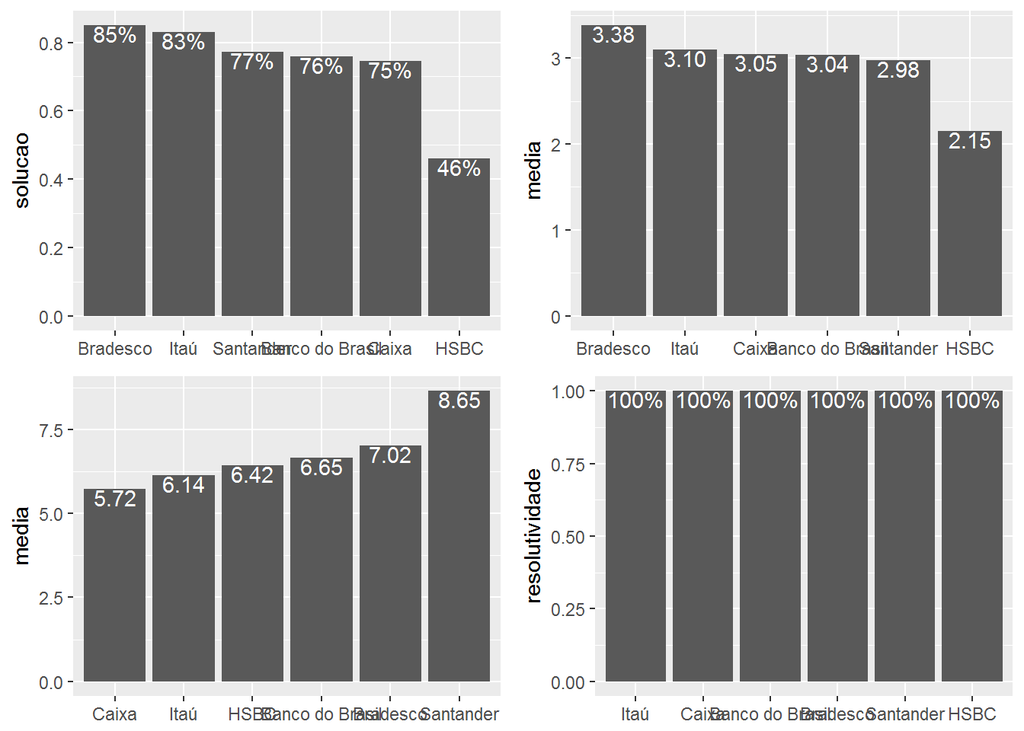

Entre os Bancos, o Bradesco tem os melhores índices de solução e satisfação e o HSBC, apesar de poucas reclamações, tem índices de solução e satisfação muito abaixo aos concorrentes.

Grupo de Problema por Empresa

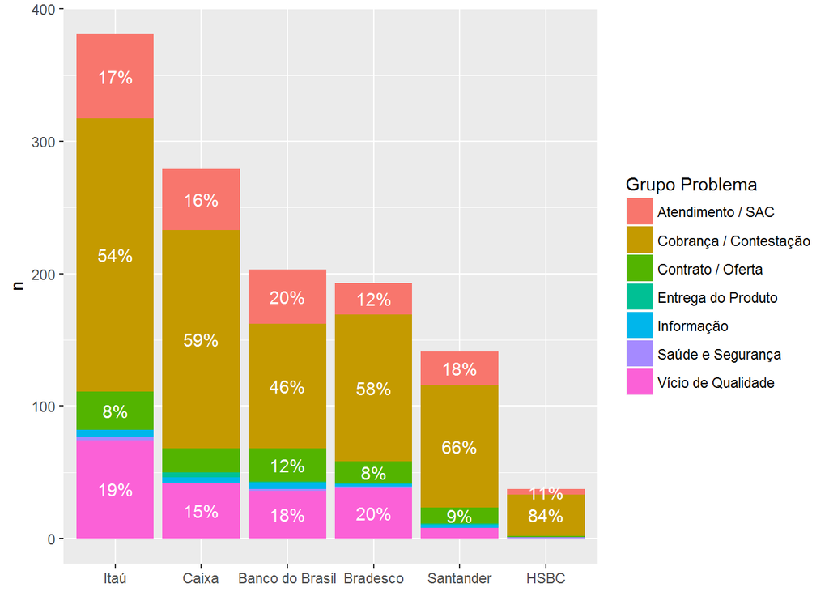

Neste gráfico, observa-se uma distribuição parecida dos grupos de problema entre as empresas.

Nota Média das Empresas por Estado

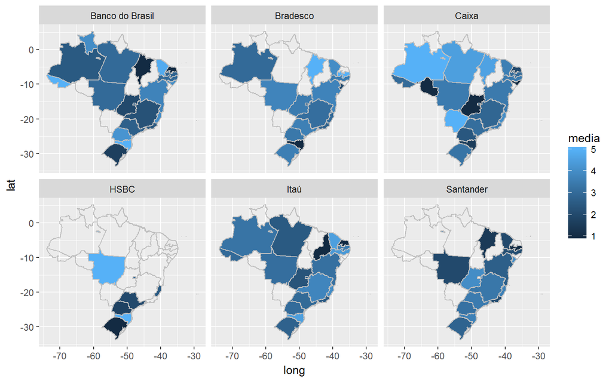

### Gráficos Finais e Sumário

Para esta seção foram escolhidos os gráficos do segmento de Telecomunicações por ter sido o campeão de reclamações e, também, por possuir mais empatia com os reclamantes.

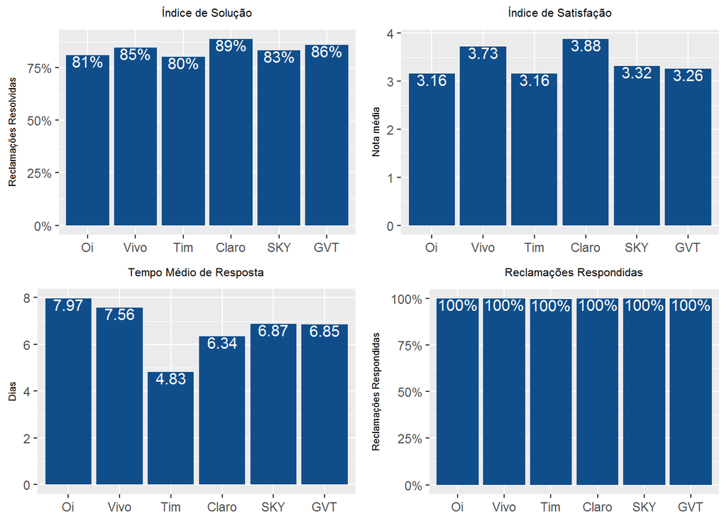

Nesta visão, temos os índices de desempenho das ampresas agrupados. Pode-se ter uma excelente idéia de como as empresas se comportam em relação às reclamações que recebem.No geral, todas as reclamações foram respondidas, mas nem todas foram resolvidas. Como analisado anteriormente, percebemos uma forte correlação entre a solução das reclamações e da nota do consumidor, portanto, nota-se que as empresas que tem melhor nota média são as empresas que tem maiores índices de solução. Como a SKY e a GVT fornecem serviços diferentes dos demais (SKY oferece TV por assinatura e GVT oferece internet), considero que alguns índices podem ser discrepantes dos demais, como a relação de solução e nota, por exemplo. A GVT possui o segundo melhor índice de solução, porém apenas o quarto maior índice de satisfação. Percebe-se, também, a ausência de correlação entre tempo de resposta e nota do consumidor, já que a Tim possui o menor tempo de resposta e tem a mesma nota da Oi, que tem o maior tempo de resposta. Ou seja, o consumidor não parece se importar muito com a rapidez do processo, desde que ele seja resolvido.

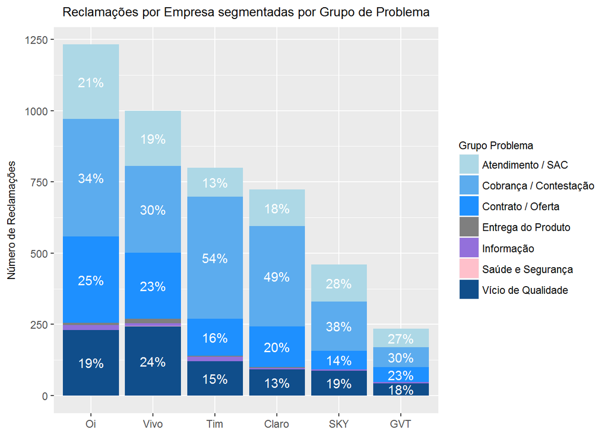

Neste gráfico, pode-se perceber que há uma diferença bem grande entre as quatro grandes empresas de telefonia em relação ao número de reclamações. Porém, o ideal seria ter a carteira de clientes de cada empresa para analisar a frequência de reclamações em relação ao número de clientes. Observa-se que todas as empresas possuem boas proporções de quatro principais grupos de problemas: Atendimento, Cobrança, Contrato e Vicio de Qualidade. O que não é surpreendente, já que essas empresas são conhecidas por causarem transtornos de diversos tipos. Dentre as quatro empresas de telefonia, nota-se que o grupo mais problemático é o de Cobrança, especialmente para a Tim e a Claro. Já as outras duas parecem sofrer um pouco mais com a qualidade do serviço e ofertas não cumpridas. A Tim parece ter o atendimento melhor que o das concorrentes.

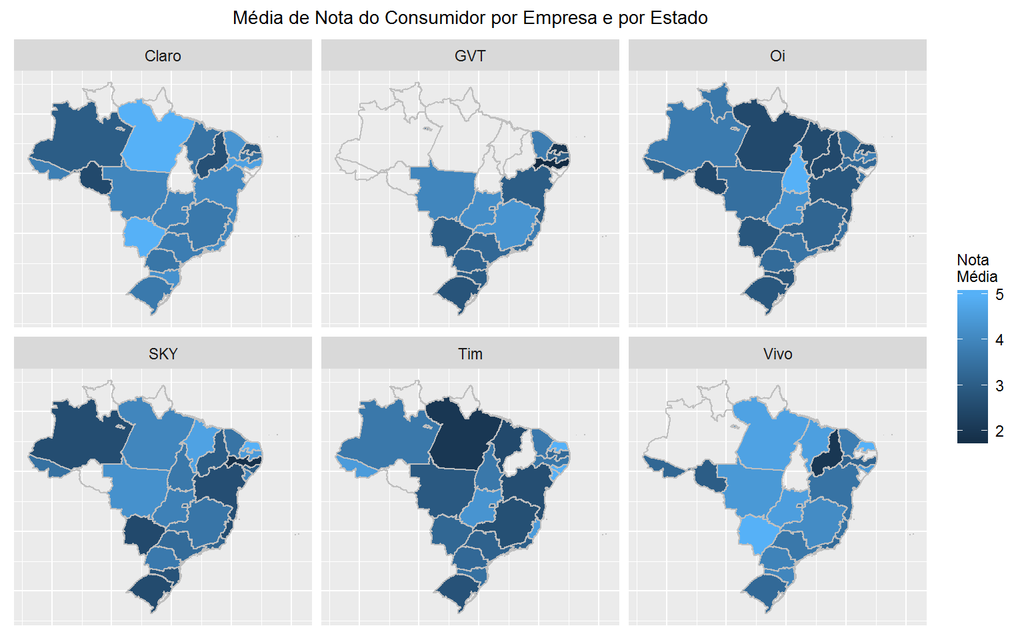

Esta visão fornece insights interessantes. Por exemplo, a GVT parece não alcançar os estados do Norte e alguns do Nordeste. O Piauí parece não ter uma boa opção de empresa de telefonia. Analisando os gráficos separadamente, pode-se notar que há disparidades grandes das notas médias entre os estados. Isso pode gerar, nas empresas, planos de ação para tentar replicar o cenário dos estados nos quais a satisfação é maior nos estados com os clientes mais insatisfeitos. No caso da Oi, os reclamantes do Tocantins parecem estar bem mais satisfeitos do que os do restante do pais. Por quê? Como essas reclamações foram resolvidas? Qual é o diferencial? Analisando os estados separadamente, também temos uma boa noção de como é a concorrência nestes. Por exemplo, no Pará, os clientes parecem estar satisfeitos com a Vivo e com a Claro, mas insatisfeitos com a Tim e com a Oi.

### Reflexões

Com esta análise, pudemos confirmar a percepção de que os consumidores brasileiros têm várias dores, dos mais diversos tipos e em diferentes segmentos de mercado, por mais que alguns destes dominem as reclamações recebidas pelo Consumidor.gov.br. Como consumidores, passamos por isso ordinariamente e sempre escutamos casos de outras pessoas. Apesar desta análise ter o poder de direcionar o cliente para a empresa que possui menor número ou os melhores índices de reclamações, acredito que ela é mais valiosa para as empresas, que podem descobrir o motivo das reclamações, o perfil dos reclamantes, o comportamento de seus concorrentes perante estas e fazer algo a respeito, a fim de melhorar seus serviços e fidelizar seus clientes.  
A escolha dessa base de dados se deu devido à minha curiosidade em relação às reclamações dos consumidores brasileiros e às empresas que geram as geram. Comecei a explorar a base e, quando percebi, já estava envolvido analisando problemas pelos quais já havia passado. Em relação à base, a pior parte é que não há muitas variáveis numéricas, impossibilitando a análise de várias variáveis correlacionadas. Em contrapartida, a base veio limpa e exigiu pouquíssimo tratamento de dados. O maior desafio foi criar o mapa coroplético do Brasil. Criar o mapa, detalhar suas características e depois fazer a segmentação por empresa exigiu muita pesquisa e paciência. Futuramente, podem ser adicionados à essa base de dados outros meses para possibilitar a análise da evolução dos indicadores das empresas ao longo do tempo. Também pode ser feito um estudo para identificar fenômenos como sazonalidade. Recentemente, foram adicionados arquivos mais atuais no site de dados abertos do governo, possibilitando essa análise.

### Referências:

Cheatsheet do ggplot2

https://www.rstudio.com/wp-content/uploads/2015/03/ggplot2-cheatsheet.pdf

Cheatsheet do dplyr

https://www.rstudio.com/wp-content/uploads/2015/02/data-wrangling-cheatsheet.pdf

Documentação das funções utilizadas

https://www.rdocumentation.org

Solução de dúvidas diversas

https://stackoverflow.com

Exemplo de mapa coroplético

http://bl.ocks.org/prabhasp/raw/5030005/